# データ観察と可視化

《学修項目》

- データの種類、質的データの要約、分割表、混合行列
- 様々なデータ可視化⼿法（質的データを中心として）
- ビッグデータの可視化、関係性の可視化、GIS情報との融合

《キーワード》

> 量的変数、質的変数、群データ、群平均、総平均、分割表、クロス集計表、観測度数、周辺度数、期待度数、リスク、オッズ、棒グラフ、パレート図、層状帯グラフ、beeswarm図、ビッグデータ可視化、関係グラフ、GIST情報

《参考文献，参考書籍》

- [1] [東京大学MIセンター公開教材 「1-3 データ観察」](http://www.mi.u-tokyo.ac.jp/pdf/1-3_data_search.pdf)[「1-5 データ可視化」](http://www.mi.u-tokyo.ac.jp/pdf/1-5_data_visualization.pdf) [《利用条件CC BY-NC-SA》](https://creativecommons.org/licenses/by-nc-sa/4.0/deed.ja)
- [2] [応用基礎としてのデータサイエンス（講談社 データサイエンス入門シリーズ）](https://www.kspub.co.jp/book/detail/5307892.html)
- [3] [データサイエンスの考え方 社会に役立つAI×データ活用のために（オーム社）](https://www.ohmsha.co.jp/book/9784274227974/)
- [4] [Pythonによるあたらしいデータ分析の教科書 第2版（翔泳社）](https://www.shoeisha.co.jp/book/detail/9784798178776)
- [5] [数理・データサイエンス・AI公開講座（放送大学）](https://www.ouj.ac.jp/booklet/2022/29_2022_MDS-AI.pdf)

## 1. データの種類、質的データの要約 [1][2]

### 1.1 データの種類 [1]

データは、事実や参考資料・情報であり、コンピューターで扱うことができる記号化・数値化されたものを指す。データの種類には、**量的変数と質的変数**の2種類があり、量的変数には比率データと間隔データが、質的変数には名義尺度と順序尺度がある。量的変数は数量で表現され、比率データと間隔データに分けられる。質的変数は数量で表現が難しく、**名義尺度と順序尺度**に分類される。名義尺度は同じ値か否かを表現し、順序尺度は大小関係を表現する。

[figure not shown]

### 1.2 質的データ [2]

対象 $i$ のある属性 $x$ について観測された数値または記号をデータと呼び $X_i$ で記す。 このとき、**属性 $x$ を 変数（variable)** と呼ぶ。 数値で与えられるデータについて、連続的な値をとるデータを連続データ、離散的な値をとるデータを離散データと言う。

データは尺度水準によっていくつかの尺度に分類される。 尺度のうち、質的データとして分類されるには、以下の2つである[2]。

- **名義尺度**：対象の観測値が（順序関係の意味のない）数値または記号の集合によって表されるとき、対象は名義尺度で観測されているといい、そのデータを名義尺度データと呼ぶ。

名義尺度データにおいては、等値関係（==）しか意味がなく、数値で表現されていても、その大小関係には意味がない。

- **順序尺度**：対象の観測値が順序関係の意味のある数値または記号の集合で表されるとき、対象は順序尺度で観測されているといい、そのデータを順序尺度データと呼ぶ。

### 1.3 質的 x 量的データの要約

ここでは、質的変数と量的変数の組のデータが与えられたとき、それらの変数間の相関関係を測ることを考える。

表1.2.2のように、$l$ カテゴリの質的変数 $x$ と、量的変数 $y$ の組データが与えられているとき、カテゴリ群と考える。このとき、群ごとに量的変数 $y$ のデータが分けられている（ベクトル化されている）状況（表1.2.3) を考える [2]。

表1.2.2 量質混在2変数データ、表1.2.3 $l$カテゴリ群のデータ（[2]より引用）

[figure not shown]

#### 1.3.1 群データ、群平均、総平均

$x_j (j = 1, 2, \cdots, l)$ を質的変数とし、$y_{ij} (i = 1, 2, \cdots, n_j; j = 1, 2, \cdots, l)$ を群 $j$ に属する $i$番目のデータとする。 このようなデータを**群データ**と呼ぶ。 このとき、**群平均** $\bar{y}_i$ およびすべてのデータの**総平均** $\bar{y}$ は、それぞれ以下で表される[2]。

[figure not shown]

ここで、$n = \sum_{j=1}^{l}n_j$ （データ数の総和） である。

カテゴリ$l$が群（つまり、ある性質$l$によって性格づけられている）と仮定したとき、群平均 $\bar{y}_i$ を用いて、それぞれの群でデータの平均に差があるのか無いのかを判別できる。

#### 1.3.2 全分散、群内分散、群間分散

群平均 $\bar{y}_i$ および総平均 $\bar{y}$ を用いて、**全分散** $s^2_y$、**群内分散** $w^2_y$、**群間分散** $b^2_y$ が、それぞれ以下で定義される[2]。

[figure not shown]

ここで、$n = \sum_{j=1}^{l}n_j$ （データ数の総和） である。

全分散 $s^2_y$、群内分散 $w^2_y$、群間分散 $b^2_y$ について等式 $s^2_y = w^2_y + b^2_y$ が成立する。全分散の中で群間分散が相対的に大きいということは、量的変数が質的変数に大きく影響を受けている（カテゴリによってバラツキに差がある）と考えることができる。逆に、群間分散が相対的に小さいということは、その影響が小さい（カテゴリによってバラツキにあまり差が無い）と考えることができる。

この考え方に基づいて、質的変数と量的変数の関係の強さを表す指標である **相関比** $\eta^2_{xy}$ が以下で定義される[2]。相関比は0から1の間をとり、質的変数$x$の変化に量的変数$y$が影響を受けなければ0となり、関係が強い（相関がある）ほど1に近づく。

[figure not shown]

### 1.4 質的 x 質的データの要約

#### 1.4.1 クロス集計表と度数分布 [1]

複数の項目を組み合わせ、合計や平均、標準偏差などを集計した「**クロス集計表**」は、データの全体像を把握するのに有用であるが、データのばらつきを理解するのは困難である。 そこで、データを適当な区間に分け、各区間に含まれるデータ数を表にまとめた「**度数分布**」を用いることで、データの傾向を把握することができる。 度数分布は、データ数が多くても全体の傾向がわかりやすくなるため、データの解析において重要な役割を果たしている。

[figure not shown]

### 1.4.2 質的データ間における観測度数、周辺度数、期待度数 [2]

ここでは、ともに質的な2つの変数の組のデータが与えられているときの集計と要約について考えてみる。

$N$ 個の対象について $n$ カテゴリの値 $x_i (i = 1, 2, \cdots, n)$ のいずれかをとる変数 $x$ と、$m$ カテゴリの値 $y_j (j = 1, 2, \cdots, m)$ のいずれかをとる変数 $y$ の組データが与えられているとする（表1.2.4)。 このとき $N$ 個のデータの中で $x=x_i, y=y_j$ となる対象の個数（度数）を $f_{ij}$で表し、表1.2.5 の形でまとめたものを**分割表あるいはクロス集計表**と呼ぶ[2]。 分割表を用いた集計については、表中の値は度数（対象の個数）であることもあるし、全体数 $N$ で割った比率（パーセンテージ）である場合もあるが、相対的な意味は変わらない。

表1.2.4 質的な2変数データの組情報、表1.2.5 $n \times m$ 分割表（[2]より引用）

[figure not shown]

#### 1.4.3 観測度数、周辺度数、期待度数

2つの質的変数 $x, y$ について、データが $n \times m$ 分割表（表1.2.5） の形で与えられているとき、$x=x_i, y=y_j$ となる対象の個数（度数）を**観測度数** $f_{ij}$と呼ぶ。

また、**周辺度数** $f_{i\cdot}, f_{\cdot j}, f_{\cdot\cdot}$は、それぞれ以下で定義される[2]。周辺度数$f_{i\cdot}, f_{\cdot j}$は、それぞれ変数 $x_i$, $y_j$ を固定した場合の度数と考えることができる。$f_{\cdot\cdot}$は変数$x,y$を固定しないので、全個数 $N$ と一致する。

[figure not shown]

周辺度数を用いて、変数$x,y$が無関係な場合の度数（つまり周辺度数を固定した場合、周辺度数に比例するようにデータを配分したときの度数）としての**期待度数** $e_{ij} = \frac{f_{i\cdot} \cdot f_{\cdot j}}{N}$ が定義できる。

#### 1.4.4 2x2分割表の要約(1) 一致係数 [2]

特に、表1.2.8 の形で与えられる2値（ある/ない、Ture/False）の質的変数については、さらに多くの関連性（一致）の指標が提案されている[2]。

表1.2.8 2x2分割表（[2]より引用）

[figure not shown]

表1.2.8において、変数 $x, y$ が2値 $x=\{x_1, x_2\}, y=\{y_1, y_2\}$ を取るとき、**Jaccard係数** $s^J_{xy}$、**Russel-Rao係数** $s^R_{xy}$、**単純一致係数** $s^S_{xy}$ はそれぞれ以下で定義される。

[figure not shown]

一致の指標としては比率であるので0から1までの値を取る。係数が1に近いほど変数間の関連が強く、0に近いほど関連が弱い。ここで$x_1,y_1$が正例（ある、True）、$x_2,y_2$が負例（ない、False）であるとすると、正例と負例に特に制限がなければ単純一致係数を用いる。一方、正例のみに興味があるときにはJaccard係数、Russel-Rao係数を用いることがある（負例に興味がない、意味が無いと考えている時）。

【計算例】 具体的な2x2分割表として表1.2.9について考える[2]。 今回の観測データ（$N$=200）が、例えば変数 $x, y$ として、変数$x$：毎食後必ず歯を磨く（$x_1$=はい、$x_2$=いいえ）、変数$y$：歯周病の経験の有無（$y_1$=ない、$y_2$=ある）、観測度数は各々の回答件数であったとする。総数 $N$=200 のうち、歯をしっかり磨いている（$x_1$）かつ歯周病になったことが無い（$y_1$）ケースは10ある。逆にあまり歯を磨いていない（$x_2$）かつ歯周病になった（$y_2$）ケースは100ある。周辺度数を見ると、歯をあまり磨かない回答の割合が、しっかり磨く回答の3倍にのぼっている。他方、歯周病になったという回答の割合が、歯周病になったことは無いという回答の2.3倍ある。

表1.2.9 2x2分割表の例（[2]より引用）

[figure not shown]

一方、こういった負例も含めた総合的な解釈としては、単純一致係数により 55% は歯磨き習慣と歯周病との関連があるとも言える。つまり、**どのような観点からデータ分析と研究を行いたいか、によって正例・負例の定義、採用する一致係数の扱いが異なってくる**(もちろん、医学的な因果関係の解明は、データサイエンスとは別の領域になる)。

#### 1.4.5 2x2分割表の要約(2) リスク（差・比）、オッズ（比） [2]

表1.2.8 の形で与えられる2値（ある/ない、Ture/False）の質的変数について、変数 $x$ が要因（条件）であり、変数 $y$ が結果であるという前提で、要因に占める結果ありの割合、また結果どうしの比について指標が提案されている[2]。

表1.2.8において、前者は**リスク** $R$ として $a/(a+b)$, $c/(c+d)$ で定義する。後者は**オッズ** $O$ として $a/b$, $c/d$ で定義する。 リスク(オッズ）は要因 $x$ が 2値 $x=\{x_1, x_2\}$ どちら かのケースであるから、**リスク差（RD）・リスク比（RR）、オッズ比（OR）**を計算することで有意な指標として利用できる。それぞれの指標は以下で定義される。

[figure not shown]

【計算例】 具体的な2x2分割表として、再び表1.2.9について考える[2]。 変数$x$：毎食後必ず歯を磨く（$x_1$=はい、$x_2$=いいえ）が要因であり、変数$y$：歯周病の経験の有無（$y_1$=ない、$y_2$=ある）が結果であると仮定する（あくまで仮定である。医学的な因果関係は別の課題）。 3つの指標を計算するとそれぞれ、RD$=-2/15$、RR$=3/5$、OR$=1/2$ となる。

まず RD がマイナスの値を取っているし、RR が 比3:5であること、ORについても比1:2であることから、結果への影響は 要因2 の方が高いと判断される。もちろん、どの指標が利用できるかは対象とするデータ分析研究の目的・設計による。

（再掲）表1.2.9 2x2分割表の例（[2]より引用）

[figure not shown]

あらかじめ集団を条件で2つに分けておき、それらの集団を追跡してどのような結果になるか調査する手法を「コホート研究(cohort study)、前向き研究（prospective study)」と言う。前向き研究の場合には最初に対象集団を固定しているから、リスク比(RR)、オッズ比(OR)とも有意である。

他方、ある結果となった集団とそうでない集団に対して、要因の有無を（逆問題として）調査する手法を「ケースコントロール研究（case control study)、後向き研究（retrosp ective study)」と言う。後向き研究の場合はオッズ比(OR)は利用可能であるが、対象集団を固定していないのでリスク比(RR)は利用できない（そうでない集団はいくらでも増やすことができる。今回の具体例だと、「自業自得」な層は後でいくらでも集めてくることができる）。

#### 1.4.6 2x2分割表の要約(3) 混合行列、正解率、精度、再現率、特異度、F値 [2]

表1.2.8 の形で与えられる2値（ある/ない、Ture/False）の質的変数について、特に変数 $x$ が真値、変数 $y$ が予測値、$\langle x_1,y_1 \rangle$ が正例、$\langle x_2,y_2 \rangle$ が負例である状況を考える。このとき、2x2分割表は特に「**混合行列**」と呼ばれる[2]。

混合行列での各観測度数の呼び方について、aは**真陽性**(True Positive, TP)、bは**偽陰性**(False Negative, FN)、cは**偽陽性**(False Positive, FP)、dは**真陰性**(True Negative, TN) と呼ばれる。

（再掲）表1.2.8 2x2分割表、表1.2.10 混合行列（[2]より引用）

[figure not shown]

混合行列においてTP/FN/FP/TNが得られたとき、真値と予測値との間での要約指標として、**正解率**(accuracy)、**精度あるいは適合度**(precision）、**感度あるいは再現率**（recall)、**特異度**(specificity)の4つの指標が、それぞれ以下で定義される。これらは機械学習系で得られた予測モデルの評価時において重要な指標となる。

[figure not shown]

精度と再現率はトレードオフの関係にある。なぜなら、偽陽性FPと偽陰性FNがそれぞれの分母に入っていて、精度を上げようとするならFPを小さくする方策つまり厳しく正例判定を行う必要があるが、他方再現率を上げようとするならFNを小さくする方策つまり厳しく負例判定（=正例判定を緩くする）を行う必要があるためである。 そこで、これらのバランスをとって、両者の調和平均で定義されたのが**F値**である。

[figure not shown]

## 2. 基本的なデータ可視化手法（質的データを中心として） [2]

### 2.1 データ可視化の目的

可視化の主な目的は「比較する」「変化を見る」「構成を見る」「分布を見る」「相関を知る」の5つに分けられる。

[figure not shown]

表2.1は、可視化の目的とデータの尺度に応じて基本的なグラフを分類したものであり、それぞれのグラフ単独での目的に基づいて分類していることが明記されている（同じグラフを複数並べての比較は含まれていない） [2]。

（再掲）表2.1 データの量質 x 目的ごとの可視化法（[2]より引用）

[figure not shown]

（再掲）表2.2 データの量質 x 変数の数ごとの可視化法（[2]より引用）

[figure not shown]

以下では、質的データを主な対象とし、可視化・観察・分析する手法のいくつかについて説明していく。

### 2.2 1変数 量的x質的データの可視化

#### 2.2.1 グラフによる可視化(1) 棒グラフ

[figure not shown]

- [香川県 | うどん県統計情報コーナー](https://www.pref.kagawa.lg.jp/tokei/sogo/udonken/kfvn.html)

#### 2.2.2 Pythonによる棒グラフ生成の実装例

- [オリジナルデータとプログラム例（公開教材[1]）](https://github.com/MDASH-shinshu/MDASH-T-DS/tree/main/3/resources/additional_material/p5_map/3_bar)

```python
# CSVデータを カレントディレクトリ直下のフォルダ（一時作業領域）へダウンロードする．
!wget -nc https://raw.githubusercontent.com/MDASH-shinshu/MDASH-T-DS/main/3/resources/udon.csv

# wgetしなくても，Google colab.の左メニュー [ファイル] アイコンをクリックして，ブラウザへファイルをドラッグ＆ドロップしても可

# ファイル (udon.csv)がダウンロード・配置できたことを確認する
!ls -al ./
```

```
File ‘udon.csv’ already there; not retrieving.

total 548
drwxr-xr-x 1 root root   4096 Apr  9 01:22 .
drwxr-xr-x 1 root root   4096 Apr  8 23:41 ..
-rw-r--r-- 1 root root  16749 Apr  9 01:23 band.png
-rw-r--r-- 1 root root    153 Apr  9 01:03 capacity_ratio.csv
-rw-r--r-- 1 root root  33860 Apr  9 01:07 circle.png
drwxr-xr-x 4 root root   4096 Apr  6 13:38 .config
-rw-r--r-- 1 root root 460676 Apr  9 00:26 house_prices_train.csv
drwxr-xr-x 2 root root   4096 Apr  9 01:02 .ipynb_checkpoints
-rw-r--r-- 1 root root   7943 Apr  9 00:26 JJlHw.csv
-rw-r--r-- 1 root root     50 Apr  9 00:07 pareto_data.csv
drwxr-xr-x 1 root root   4096 Apr  6 13:39 sample_data
-rw-r--r-- 1 root root     65 Apr  9 00:26 udon.csv
```

```python
# オリジナルのCSVファイルをpandasで読み込んでデータフレームdfに格納
import pandas as pd
import matplotlib.pyplot as plt
df = pd.read_csv('udon.csv', header=None)
df.columns = ['city','volume']
df.head()
```

|  | city | volume |
| --- | --- | --- |
| 0 | Tokyo | 10594 |
| 1 | Osaka | 9026 |
| 2 | Takamatsu | 20807 |
| 3 | Naha | 3271 |
| 4 | Average | 9838 |

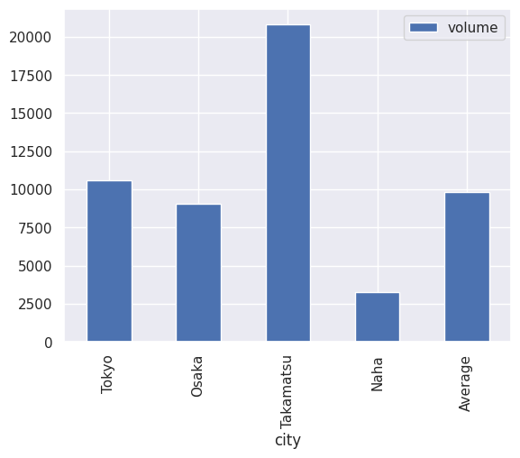

```python
# mathplot経由でデータフレームの棒グラフを表示する
df.plot.bar('city', 'volume')
```

### 2.2.3 グラフによる可視化(2) パレート図

パレート図は、度数を棒グラフで表示し、累積相対度数を折れ線グラフで表示するグラフで、品質管理の7つ道具の1つである。左側の縦軸に度数を、右側の縦軸に累積相対度数を表示し、比較と構成の把握を同時に行える。項目を多い順に表示し、全体に占める累積比率をパーセントで表す。

図1.3.1は、有名なタイタニック号沈没事故の死亡者数に関するデータをパレート図で可視化したものである。 乗組員、3等、2等、1等客室の順で死亡者数が多い。乗組員と3等客室の船客で死亡者の75%以上を占めている。

[figure not shown]

図1.3.1 パレート図（タイタニックデータ）（[2]より引用）

#### 2.2.4 Pythonによるパレート図生成の実装例

- [オリジナルデータとプログラム例（【python】matplotlibでパレート図を作成する方法](https://mori-memo.hateblo.jp/entry/2022/06/05/224841)

```python
# CSVデータを カレントディレクトリ直下のフォルダ（一時作業領域）へダウンロードする．
!wget -nc https://raw.githubusercontent.com/MDASH-shinshu/MDASH-T-DS/main/3/resources/pareto_data.csv

# wgetしなくても，Google colab.の左メニュー [ファイル] アイコンをクリックして，ブラウザへファイルをドラッグ＆ドロップしても可

# ファイル (pareto_data.csv)がダウンロード・配置できたことを確認する
!ls -al ./
```

```
File ‘pareto_data.csv’ already there; not retrieving.

total 548
drwxr-xr-x 1 root root   4096 Apr  9 01:22 .
drwxr-xr-x 1 root root   4096 Apr  8 23:41 ..
-rw-r--r-- 1 root root  16749 Apr  9 01:23 band.png
-rw-r--r-- 1 root root    153 Apr  9 01:03 capacity_ratio.csv
-rw-r--r-- 1 root root  33860 Apr  9 01:07 circle.png
drwxr-xr-x 4 root root   4096 Apr  6 13:38 .config
-rw-r--r-- 1 root root 460676 Apr  9 00:26 house_prices_train.csv
drwxr-xr-x 2 root root   4096 Apr  9 01:02 .ipynb_checkpoints
-rw-r--r-- 1 root root   7943 Apr  9 00:26 JJlHw.csv
-rw-r--r-- 1 root root     50 Apr  9 00:07 pareto_data.csv
drwxr-xr-x 1 root root   4096 Apr  6 13:39 sample_data
-rw-r--r-- 1 root root     65 Apr  9 00:26 udon.csv
```

```python
# オリジナルのCSVファイルをpandasで読み込んでデータフレームdfに格納
import numpy as np
import pandas as pd
import seaborn as sns
import matplotlib.pyplot as plt
df = pd.read_csv('pareto_data.csv', header=None)
df.columns = ['label','volume']
df.head()
```

|  | label | volume |
| --- | --- | --- |
| 0 | APPLE | 20 |
| 1 | BANANA | 40 |
| 2 | CACAO | 80 |
| 3 | DURIAN | 5 |
| 4 | EGG PLANT | 15 |

```python
# パレート図を生成する関数の定義 https://mori-memo.hateblo.jp/entry/2022/06/05/224841
def pareto(df, label_name, cnt_name):
    ''' plot pareto chart
    input
      df: data for plotting (DataFrame)
      label_name: row name for label (str)
      cnt_name: row name for count (str)
    '''
    label = df[label_name].tolist()
    cnt = df[cnt_name].tolist()
    data = pd.DataFrame(label, columns=['label'])
    data['volume'] = cnt
    data = data.sort_values(by='volume', ascending=False)
    sum_data = data['volume'].sum()
    data['accum'] = np.cumsum(data['volume'])
    data['accum_ratio'] = data['accum'] / sum_data * 100

    labels = len(data)

    percent_labels = [str(i) + "%" for i in np.arange(0, 100+1, 10)]
    accum_data = [0] + data['accum_ratio'].tolist()
    fig, ax = plt.subplots()
    bar = ax.bar(range(labels), data['volume'], align="edge", width=1, label=cnt_name)
    ax.set_ylim([0, sum_data])
    ax.set_xlim([0, labels])
    ax.set_xticks([0.5 + i for i in range(labels)])
    ax.set_xticks([1 + i for i in range(labels)], minor=True) #副目盛り
    ax.set_xticklabels(data['label'].tolist(),rotation = -90)
    ax.set_yticks(np.arange(0, sum_data+1, sum_data / 10))
    ax.grid(axis='x')
    ax.grid(axis='x', ls=':', which='minor') #副目盛り
    ax.set_xlabel(label_name)
    ax.set_ylabel(cnt_name)

    twin_ax=ax.twinx()
    twin_ax.plot(range(labels + 1), accum_data, marker='o', color='orange', label='cumulative ratio', linewidth=2.0)
    twin_ax.set_ylabel('cumulative ratio')
    twin_ax.set_ylim([0, 100])
    twin_ax.set_yticks(np.arange(0, 100+1, 10))
    twin_ax.set_yticklabels(percent_labels)
    twin_ax.grid(False)
    fig.legend(loc="center right", bbox_to_anchor=(1,0.5), bbox_transform=ax.transAxes)
    plt.tight_layout()
    plt.show()
```

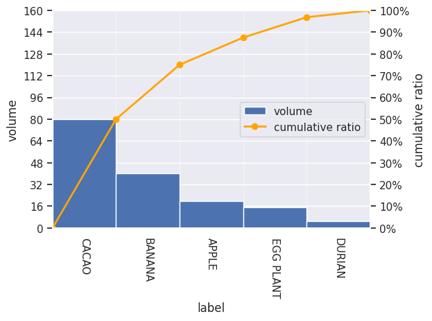

```python
# パレート図の表示
pareto(df, 'label', 'volume')
```

### 2.3 2変数・多変数 量的x質的データの可視化

#### 2.3.1 グラフによる可視化(3) 円グラフ、帯グラフ

[figure not shown]

- [資源エネルギー庁 | 平成30年度エネルギーに関する年次報告（エネルギー白書2019）](https://www.enecho.meti.go.jp/about/whitepaper/2019html/2-1-4.html)

[figure not shown]

#### 2.3.2 Pythonによる円グラフ、帯グラフ生成の実装例

- [オリジナルデータとプログラム例（公開教材[1]）](https://github.com/MDASH-shinshu/MDASH-T-DS/tree/main/3/resources/additional_material/p12_band/Ex1)

```python
# CSVデータを カレントディレクトリ直下のフォルダ（一時作業領域）へダウンロードする．
!wget -nc https://raw.githubusercontent.com/MDASH-shinshu/MDASH-T-DS/main/3/resources/capacity_ratio.csv

# wgetしなくても，Google colab.の左メニュー [ファイル] アイコンをクリックして，ブラウザへファイルをドラッグ＆ドロップしても可

# ファイル (capacity_ratio.csv)がダウンロード・配置できたことを確認する
!ls -al ./
```

```
File ‘capacity_ratio.csv’ already there; not retrieving.

total 548
drwxr-xr-x 1 root root   4096 Apr  9 01:22 .
drwxr-xr-x 1 root root   4096 Apr  8 23:41 ..
-rw-r--r-- 1 root root  16749 Apr  9 01:23 band.png
-rw-r--r-- 1 root root    153 Apr  9 01:03 capacity_ratio.csv
-rw-r--r-- 1 root root  33860 Apr  9 01:07 circle.png
drwxr-xr-x 4 root root   4096 Apr  6 13:38 .config
-rw-r--r-- 1 root root 460676 Apr  9 00:26 house_prices_train.csv
drwxr-xr-x 2 root root   4096 Apr  9 01:02 .ipynb_checkpoints
-rw-r--r-- 1 root root   7943 Apr  9 00:26 JJlHw.csv
-rw-r--r-- 1 root root     50 Apr  9 00:07 pareto_data.csv
drwxr-xr-x 1 root root   4096 Apr  6 13:39 sample_data
-rw-r--r-- 1 root root     65 Apr  9 00:26 udon.csv
```

```python
# オリジナルのCSVファイルをpandasで読み込んでデータフレームdfに格納
import pandas as pd
import matplotlib.pyplot as plt
data = pd.read_csv('capacity_ratio.csv', header=0)
data.columns = ['category', '2010','2015']
data.head()
```

|  | category | 2010 | 2015 |
| --- | --- | --- | --- |
| 0 | Thermal | 0.654291 | 0.848091 |
| 1 | Hydror | 0.072904 | 0.083733 |
| 2 | Nuclear | 0.250754 | 0.009071 |
| 3 | Renewable | 0.022051 | 0.059105 |

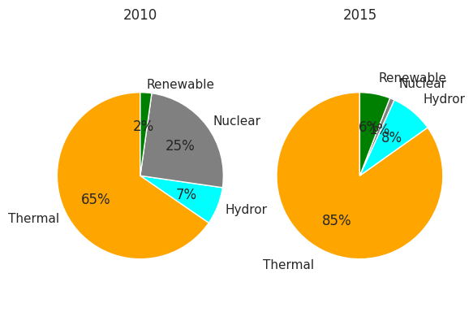

```python
#　　Figure, labelを設定
fig = plt.figure()
labels=["Thermal", "Hydror", "Nuclear", "Renewable"]
data.index = labels
colors = ["orange", "cyan", "gray", "green"]

#　　2010年の円グラフ
fig.add_subplot(1, 2, 1)
plt.title("2010")
plt.pie(data['2010'], labels= data.index, startangle=90, autopct="%1.0f%%", colors=colors, labeldistance=1.1)
plt.axis('equal')

#　　2015年の円グラフ
fig.add_subplot(1, 2, 2)
plt.title("2015")
plt.pie(data['2015'], labels= data.index, startangle=90, autopct="%1.0f%%", colors=colors, labeldistance=1.2)
plt.axis('equal')

#　　グラフを保存
plt.savefig('circle.png')
```

```python
#　　帯グラフ用にデータを加工
years = ['2015', '2010']
data = 100* data[years]
data
```

|  | 2015 | 2010 |
| --- | --- | --- |
| Thermal | 84.809115 | 65.429070 |
| Hydror | 8.373285 | 7.290421 |
| Nuclear | 0.907058 | 25.075440 |
| Renewable | 5.910542 | 2.205068 |

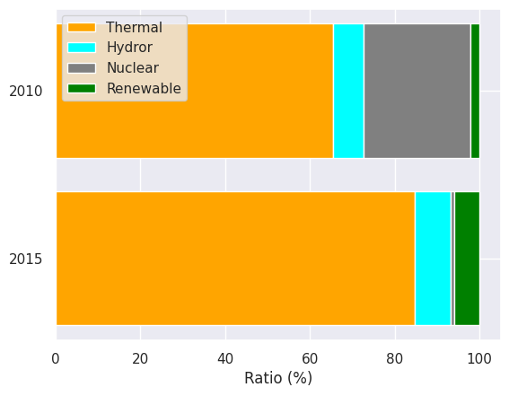

```python
#　　Figure, ax軸, label, 色を設定
fig = plt.figure()
ax = fig.add_subplot(1, 1, 1)
labels=["Thermal", "Hydror", "Nuclear", "Renewable"]
data.index = labels
colors = ["orange", "cyan", "gray", "green"]
color_list = dict(zip(labels, colors))

#　　縦軸設定、グラフを出力
label_y = ["2015", "2010"]
for i in data.index:
    ax.barh(label_y, data.loc[i], left=data.loc[:i].sum()-data.loc[i], color=color_list[i])

#　　凡例を出力
ax.legend(data.index)
plt.xlabel('Ratio (%)')

#　　グラフを保存
plt.savefig('band.png')
```

ヒートマップ、モザイクプロット、散布図については、chap.2を参考にされたい。